# Visualizing Predictions

Author

Kris Sankaran

Published

September 1, 2026

[Reading](https://ema.drwhy.ai/partialDependenceProfiles.html) Code

## Motivation

1. Partial dependence profiles (PDP), individual conditional expectation (ICE) plots, and accumulated local effects (ALE) are types of global explainability methods. They can be applied post-hoc to any model and try to reveal how the model relates a predictor variable/set of predictor variables with the response.
2. Partial dependence profiles were first introduced as a minor point in an influential paper about gradient boosting. ICE and ALE were introduced to address some limitations of PDP, mainly related to the fact that prediction surfaces can become complicated in high-dimensions and when many interactions are present.

## Partial Dependence Profiles

3. Let $f$ be the learned black box function. Let $x$ be its $D$-dimensional input. The idea is to ask how $f$ changes as we vary the $d$th coordinate over its range. We need to do something with the remaining coordinates; the idea of PDP is to average across them.

$$\text{PDP}_d(z) = \mathbb{E}_{p(x_{-d})}\left[f(x_d = z, x_{-d})\right] \approx \frac{1}{N}\sum_{n=1}^N f(x_d = z, x_{n, -d})$$

The highlighted part refers to manually intervening on the $d$th coordinate and setting it to $z$. If we evaluate this average across many different values of $z$, we get a PDP curve. Note that for each value $z$, we compute an average across the entire dataset – this can get slow.

4. This definition generalizes to larger-dimensional subsets of variables, but we’ll stick to one-dimensional curves for simplicity.
5. Here is some geometric intuition. We take the original samples, manually set all their $d$th coordinates to $z$, evaluate the function $f$, and then average. We repeat this for many $z$’s to trace out the partial dependence curve.

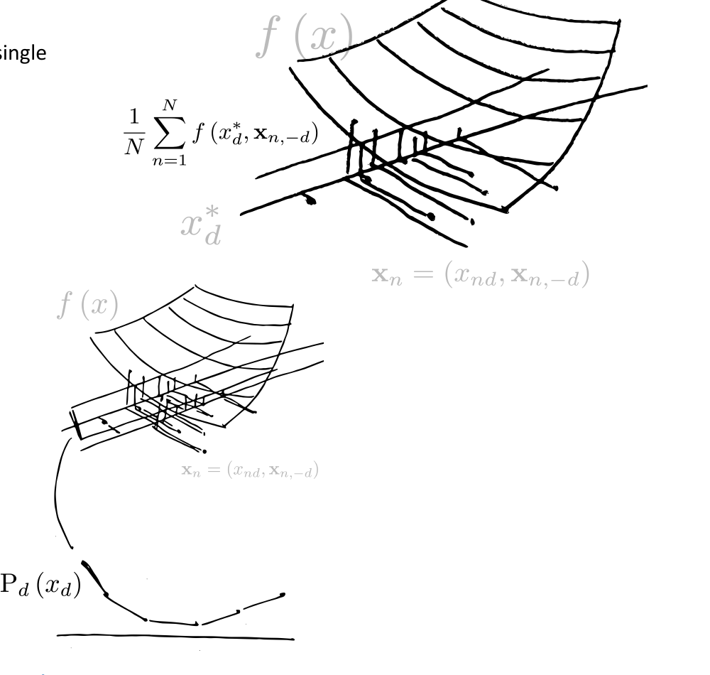

Evaluating the PDP at a single value $z = x_d^*$ (top) and repeating this across many $z$ to trace out the $\text{PDP}_d(x_d)$ curve (bottom).

## Individual Conditional Expectations

6. ICE plots consider each term in the PDP formula as its own function of $z$.

$$h_n(z) := f(x_d = z, x_{n, -d})$$

This has the nice “Ceteris Paribus” interpretation. For each sample, it traces out the curve where the $d$th coordinate is set to different values $z$ but all other coordinates are held fixed.

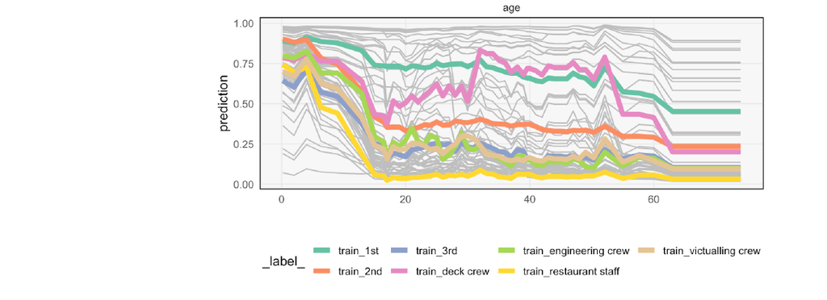

ICE (“Ceteris Paribus”) curves for a survival model fit to the Titanic dataset, colored by passenger/crew class.

8. Two common tricks for ICE plots:
- We might suspect an interaction with an unmeasured variable. This can sometimes be seen as groups of curves with different shapes, but where we don’t have a variable in the data that splits those groups. In this case, people often cluster the curves and use cluster membership as a stand in for the unobserved interacting variable.

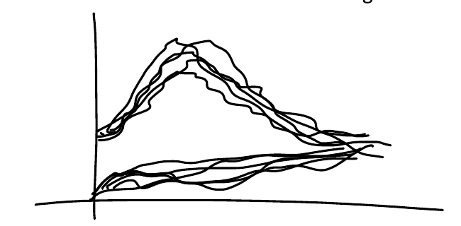

Groups of ICE curves with different shapes can suggest an interaction with an unmeasured variable; clustering the curves gives a stand-in for that variable.

- Often the curves are offset because of differences in the coordinates other than the $d$th. To see whether they nonetheless have similar shapes, it’s sometimes helpful to “center” the curves, so that they all start out equal to one another.

$$\tilde{h}_n(z) = f(x_d = z, x_{n, -d}) - f(x_d = 0, x_{n, -d})$$

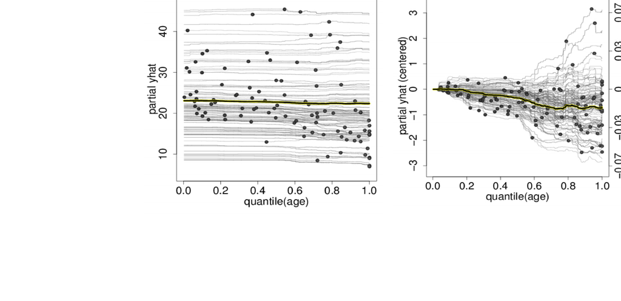

Raw ICE curves for a partial $\hat{y}$ vs. age relationship (left) and the same curves after centering (right); centering makes it easier to compare shapes across curves that start at different levels.

## Effects and Partial Residual Plots

9. Fox and Weisberg (2018) focus on visualizing effects just in the case of linear regression models. Even here, it pays to be careful when thinking about the role of interactions.
10. Suppose we are interested in the $d$th predictor in a linear regression model. They partition the predictors into $(z, v, u)$:
- $z$ - the predictor we are interested in.
- $v$ - the predictors that interact with $z$.
- $u$ - other unrelated predictors.
11. They recommend identifying a grid of values across $v$ and then tracing the function of $z$ with $v$ fixed to each of those grid points.

$$\left\{h_d(z, v)\right\}_{v \in \mathcal{G}} \equiv \left\{\begin{pmatrix}z \\ v \\ 0\end{pmatrix}^T\hat\beta\right\}_{v \in \mathcal{G}}$$

In this example $z$ = per person GDP and $v$ = country group.

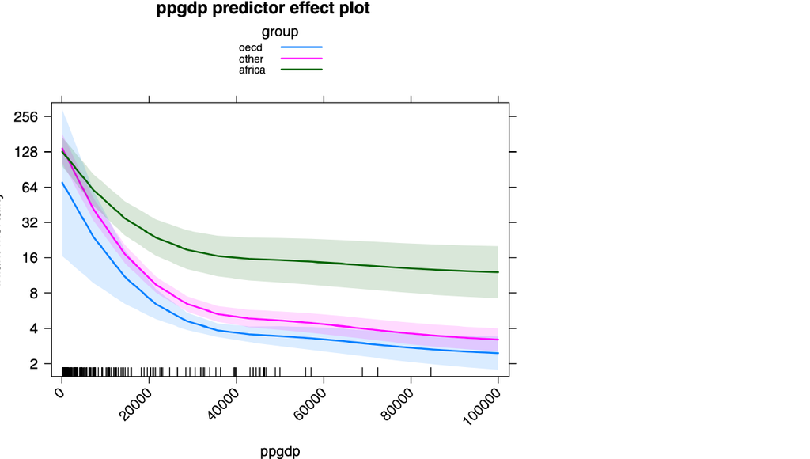

The ppgdp predictor effect plot: fitted infant mortality vs. per-capita GDP, traced separately for each of a grid of country groups (oecd/other/africa).

12. They also suggest overlying the residuals on these effects plots.

$$\begin{pmatrix}z = x_{nd} \\ v\end{pmatrix}^T \hat\beta + e(x_n)$$

(I don’t like their notation for this… though I don’t know if this is any better.)

Regardless, the idea is simple: This plot can help identify systematic structure in the residuals. E.g., if the residuals are systematically different in some regions of the $z$-space, then we might have a mis-specified model. For example, in this toy example, the residuals suggest that the model is missing an interaction term between x2 and x3.

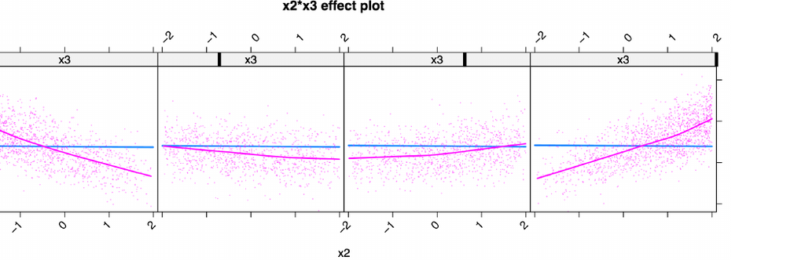

The x2*x3 effect plot with residuals overlaid; the trend in the residuals across facets suggests a missing interaction between x2 and x3.

## Probabilistic Models

13. So far, we’ve been focusing on visualizign black box models. In many settings, we might instead want to fit probabilistic models directly informed by our conceptual understanding. Visualization fits nicely into this workflow as well, and can help in building up more realistic, but still interpretable, models.
14. Exploratory data analysis and model building work synergistically. In real-world applications, visualization guides selection toward more reasonable models.
15. Models’ exact forms are typically unknown initially, though several plausible candidates usually exist. Exploratory work eliminates some options while revealing unexpected connections.
16. As an illustration, consider PM2.5 monitoring. A researcher is interested in monitoring the level of PM2.5, a type of small air particulate that can be bad for public health. High-quality weather station data apply locally; lower quality satellite data provide global coverage. A calibration model using station measurements to adjust satellite readings is needed.

```r
f <- tempfile()
download.file("https://github.com/jgabry/bayes-vis-paper/blob/master/bayes-vis.RData?raw=true", f)
GM <- get(load(f))
GM@data <- GM@data |>
    mutate(
        log_pm25 = log(pm25),
        log_sat = log(sat_2014)
    )
```

17. The baseline model uses the equation $\text{station} = a + b \times \text{satellite}$ at co-located measurement points. The Global Burden of Disease project employed this approach through 2016.

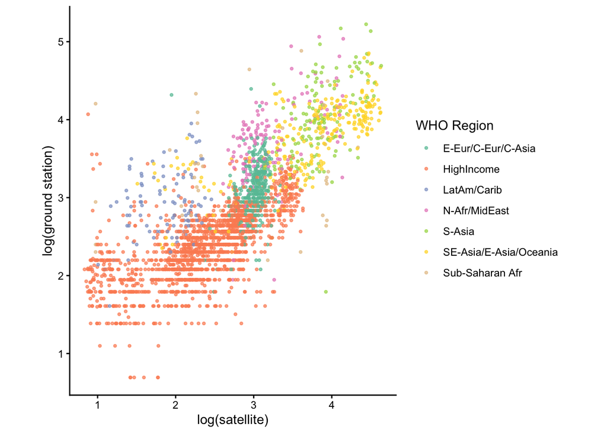

```r
ggplot(GM@data, aes(log_sat, log_pm25)) +
    geom_point(aes(col = super_region_name), size = 0.8, alpha = 0.7) +
    scale_color_brewer(palette = "Set2") +
    labs(x = "log(satellite)", y = "log(ground station)", col = "WHO Region") +
    coord_fixed()
```

18. Plotting reveals substantial heterogeneity and large residuals. The key question: What factors correlate with residuals that could enhance model performance?
- Error terms $\epsilon_i$ in equations $y_i = f(x_i) + \epsilon_i$ represent unmeasured factors determining $x$-$y$ relationships.
- Desert sand increases PM2.5 but remains invisible to satellites; residuals likely correlate with desert locations (PM2.5 underpredicted), suggesting inclusion of geographic features improves fit.
19. One hypothesis: country region significance. Fitting separate regression lines per WHO super-region reveals slope variation, suggesting models should incorporate region-specific slopes.[^1]

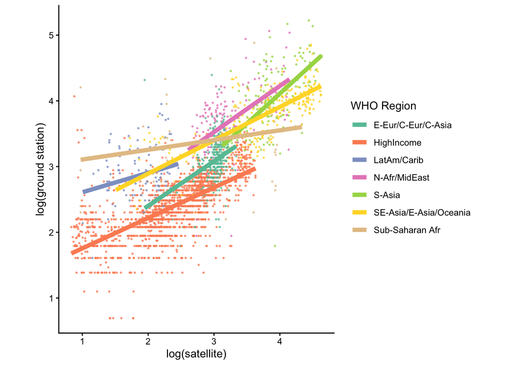

```r
ggplot(GM@data, aes(log_sat, log_pm25)) +
    geom_point(aes(col = super_region_name), size = 0.4, alpha = 0.7) +
    geom_smooth(aes(col = super_region_name), method = "lm", se = FALSE, size = 2) +
    scale_color_brewer(palette = "Set2") +
    labs(x = "log(satellite)", y = "log(ground station)", col = "WHO Region") +
    coord_fixed()
```

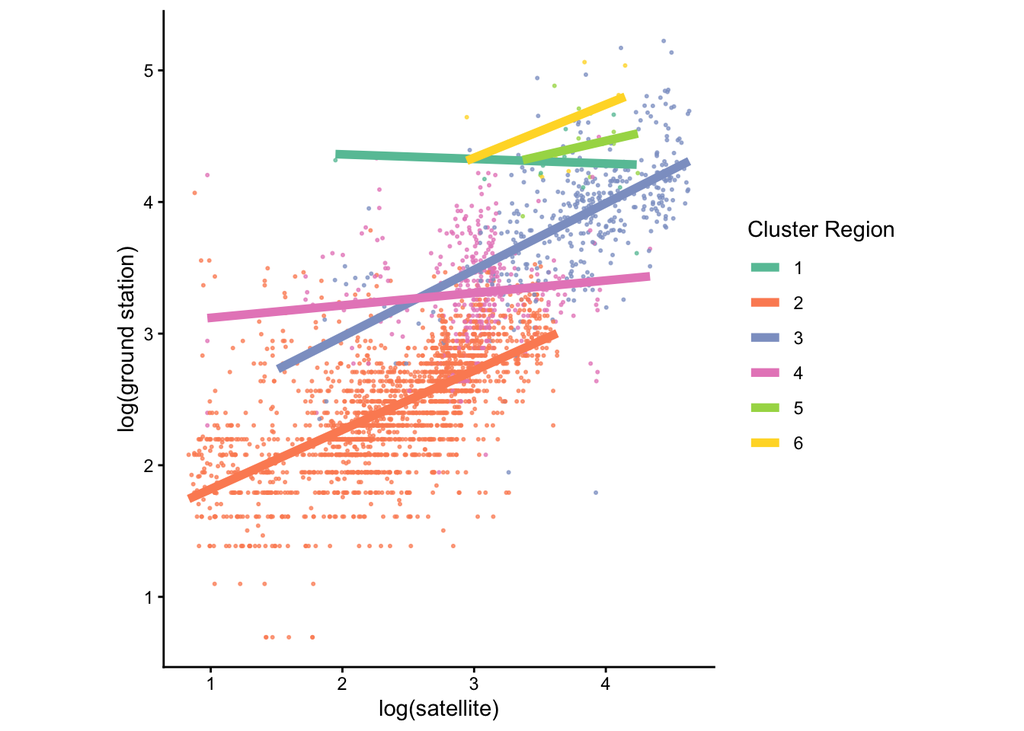

```r
average <- GM@data |>
    group_by(iso3) |>
    summarise(pm25 = mean(pm25))

clust <- dist(average$pm25) |>
    hclust() |>
    cutree(k = 6)

GM@data$cluster_region <- as.character(clust[match(GM@data$iso3, average$iso3)])
ggplot(GM@data, aes(log_sat, log_pm25)) +
    geom_point(aes(col = cluster_region), size = 0.4, alpha = 0.7) +
    geom_smooth(aes(col = cluster_region), method = "lm", se = FALSE, size = 2) +
    scale_color_brewer(palette = "Set2") +
    labs(x = "log(satellite)", y = "log(ground station)", col = "Cluster Region") +
    coord_fixed()
```

21. A model network emerges; refined comparison tools become necessary. This sets up the subject of our next notes: prior and posterior predictive checks.

## Prior and Posterior Predictives

22. How should we go about choosing between the plausible models developed from exploratory analysis? An alternative which often brings more insight into the structure of the problem than raw test-set error is to use prior and posterior predictive distributions for (visual) model comparison.

```r
library(rstan)
```

23. The prior predictive distribution helps decide whether certain model families are reasonable candidates for a problem, before formally incorporating the evidence coming from the data. The mechanism is: (a) sample parameters from the prior, and (b) simulate data from the model with those parameters.
24. Vague priors can produce implausible simulated datasets, despite being “more objective” in some sense.

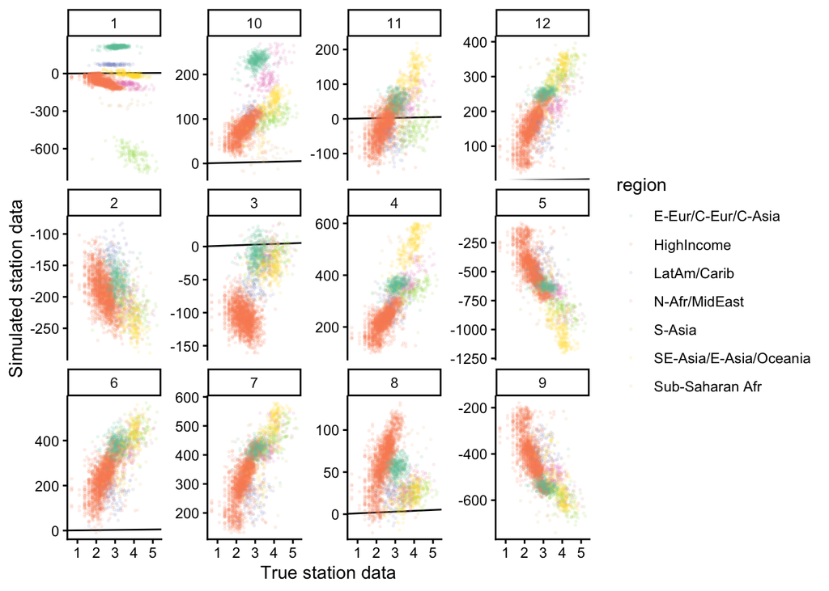

```r
prior1 <- function(Nsim) {
    tau0 <- 1 / sqrt(rgamma(1, 1, rate = 100))
    tau1 <- 1 / sqrt(rgamma(1, 1, rate = 100))
    sigma <- 1 / sqrt(rgamma(1, 1, rate = 100))
    beta0i <- rnorm(7, 0, tau0)
    beta1i <- rnorm(7, 0, tau1)
    beta0 <- rnorm(1, 0, 100)
    beta1 <- rnorm(1, 0, 100)

    epsilon <- rnorm(Nsim, 0, sigma)
    data.frame(
        log_pm25 = GM$log_pm25,
        region = GM$super_region_name,
        sim = beta0 + beta0i[GM$super_region] + (beta1 + beta1i[GM$super_region]) * GM$log_sat + epsilon
    )
}

prior1_data <- map_dfr(1:12, ~ prior1(Nsim = nrow(GM@data)), .id = "replicate")
ggplot(prior1_data, aes(log_pm25, sim)) +
    geom_abline(slope = 1) +
    geom_point(aes(col = region), alpha = 0.1, size = 0.4) +
    scale_color_brewer(palette = "Set2") +
    labs(x = "True station data", y = "Simulated station data") +
    facet_wrap(~replicate, scale = "free_y")
```

Prior predictive samples from this vague prior are on a completely implausible scale.

25. Subjective, informative priors instead produce more plausible samples, lying in a comparable range to the true data. Note, however, that samples from the prior predictive do not need to look exactly like the observed data – if they did, there would be no need to fit model parameters!

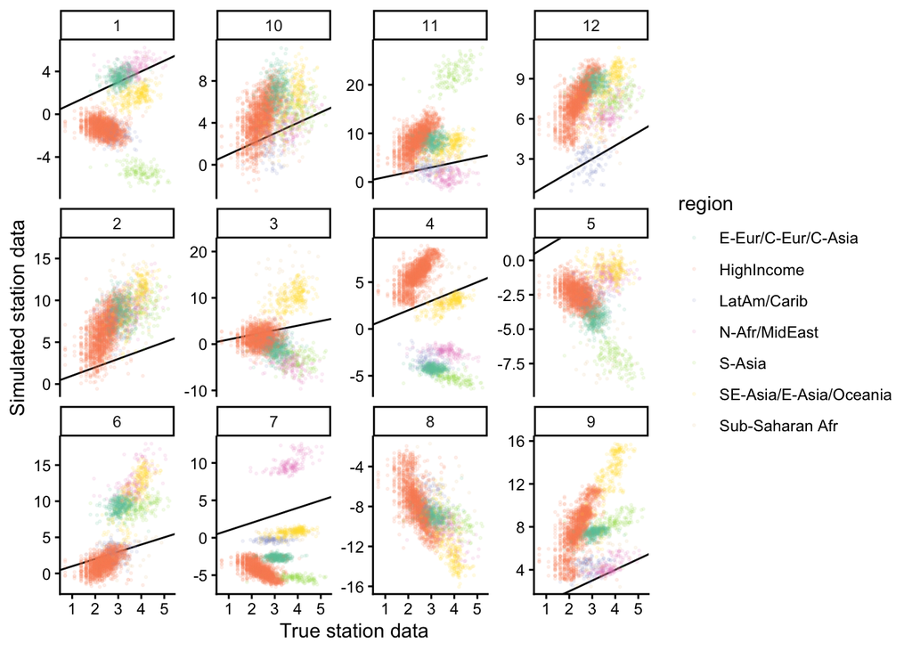

```r
prior2 <- function(Nsim) {
    tau0 <- abs(rnorm(1, 0, 1))
    tau1 <- abs(rnorm(1, 0, 1))
    sigma <- abs(rnorm(1, 0, 1))
    beta0i <- rnorm(7, 0, tau0)
    beta1i <- rnorm(7, 0, tau1)
    beta0 <- rnorm(1, 0, 1)
    beta1 <- rnorm(1, 1, 1)

    epsilon <- rnorm(Nsim, 0, sigma)
    data.frame(
        log_pm25 = GM$log_pm25,
        region = GM$super_region_name,
        sim = beta0 + beta0i[GM$super_region] + (beta1 + beta1i[GM$super_region]) * GM$log_sat + epsilon
    )
}

prior2_data <- map_dfr(1:12, ~ prior2(Nsim = nrow(GM@data)), .id = "replicate")
ggplot(prior2_data, aes(log_pm25, sim)) +
    geom_abline(slope = 1) +
    geom_point(aes(col = region), alpha = 0.1, size = 0.4) +
    scale_color_brewer(palette = "Set2") +
    labs(x = "True station data", y = "Simulated station data") +
    facet_wrap(~replicate, scale = "free_y")
```

26. Philosophically, this prior predictive analysis is based on the idea that, though probability is subjective, evidence can be used to update our beliefs. The idea of the prior predictive is to visually encode subjective beliefs about the problem under study before gathering new evidence.
27. After calibrating the prior predictive, models are fit. The posterior predictive is like the prior predictive, except that it samples model parameters from the data-informed posterior, rather than the data-ignorant prior: it represents the distribution of new datasets when drawing parameters from the posterior. The simulation mechanism is (a) draw model parameters from the posterior and (b) simulate a dataset using parameters from (a).

```r
datasets <- list(
    "lm" = with(GM@data, list(N = length(log_pm25), y = log_pm25, x = log_sat)),
    "regions" = with(
        GM@data,
        list(N = length(log_pm25), y = log_pm25, x = log_sat, group = super_region, R = n_distinct(super_region))
    ),
    "clusters" = with(
        GM@data,
        list(N = length(log_pm25), y = log_pm25, x = log_sat, group = as.integer(cluster_region), R = n_distinct(cluster_region))
    )
)

model_def <- list(
    "lm" = stan_model("https://uwmadison.box.com/shared/static/hoq1whain301bj6gj670itxabnnhvcy7.stan"),
    "hier" = stan_model("https://uwmadison.box.com/shared/static/lvouz9jj4rbkmrx5osj2dtrhj2ycdll8.stan")
)

controls <- list(max_treedepth = 15, adapt_delta = 0.99)
models <- list(
    "lm" = sampling(model_def$lm, data = datasets$lm, chains = 1, control = controls),
    "regions" = sampling(model_def$hier, data = datasets$regions, chains = 1, control = controls),
    "clusters" = sampling(model_def$hier, data = datasets$clusters, chains = 1, control = controls)
)
```

We’ve defined three models here: an ordinary linear regression (`lm`), a region-based hierarchical model, and a cluster-based hierarchical model. The hierarchical models allow different slopes for different groups.

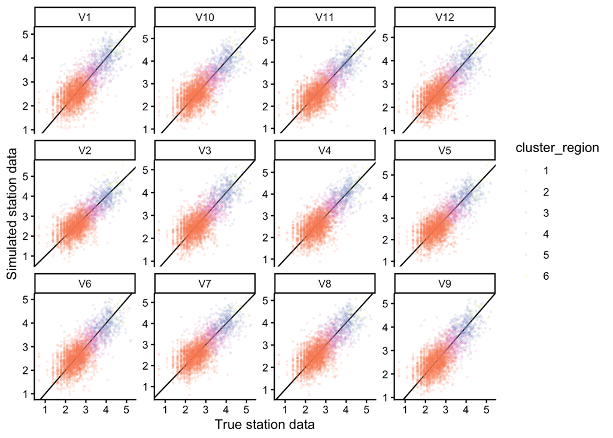

```r
posterior_samples <- as.matrix(models$clusters, pars = "y_sim")[950:961, ] |>
    t() |>
    as_tibble() |>
    bind_cols(GM@data) |>
    pivot_longer(V1:V12, names_to = "replicate", values_to = "log_pm25_sim")

ggplot(posterior_samples, aes(log_pm25, log_pm25_sim)) +
    geom_abline(slope = 1) +
    geom_point(aes(col = cluster_region), size = 0.4, alpha = 0.1) +
    scale_color_brewer(palette = "Set2") +
    labs(x = "True station data", y = "Simulated station data") +
    facet_wrap(~replicate, scale = "free_y")
```

Compared to the prior predictive, the posterior predictive is much more closely related to the true underlying dataset.

28. One subtlety is that there is a danger of overfitting features in the posterior predictive. It is best to choose features of the data that are not directly modeled (e.g., if you use slope in the model estimation, then don’t evaluate the posterior predictive using the slope, since by definition this will be well-captured).

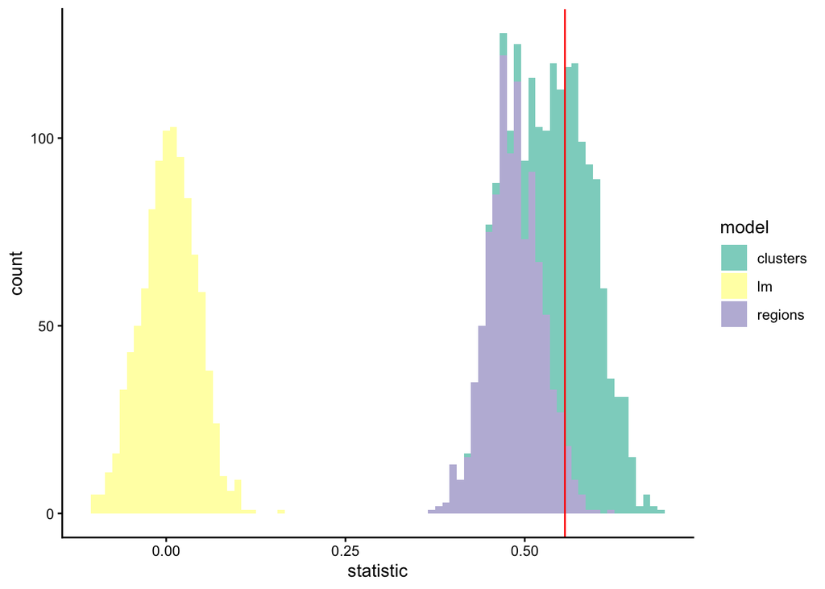

```r
apply_stat <- function(x, f) {
    z <- as.matrix(x, pars = "y_sim")
    tibble(replicate = seq_len(nrow(z)), statistic = apply(z, 1, f))
}

skew <- function(x) {
    xdev <- x - mean(x)
    n <- length(x)
    r <- sum(xdev^3) / sum(xdev^2)^1.5
    r * sqrt(n) * (1 - 1 / n)^1.5
}

posteriors <- map_dfr(models, ~ apply_stat(., skew), .id = "model")
truth <- skew(GM@data$log_pm25)
ggplot(posteriors, aes(statistic)) +
    geom_histogram(aes(fill = model), binwidth = 0.01) +
    geom_vline(xintercept = truth, col = "red") +
    scale_fill_brewer(palette = "Set3")
```

It seems that the model that uses clustering to define regions is able to simulate datasets with skewness similar to that in the real dataset.

## Footnotes

[^1]: Alternatively, this can be viewed as introducing an interaction between satellite measurements and WHO region.